# Rafa hello

# Introduction

An exploratory analysis of one year of bike rental data reveals clear usage patterns, including both **regular and occasional use.** Among regular users, **commuting** and **short-distance daytime travel such as shopping** are the two main purposes.

After careful data preprocessing, such as mindful of statistical pitfalls like outliers, low data counts in specific weather conditions, and multicollinearity, **optimal weather conditions** for high rental activity were identified.

# Key Insights

## 1. User Segments (Use Cases)

- Bike rental usage can be categorized into three main patterns:
  1. **Weekday commuting**, especially Monday through Thursday

  (Friday shows a noticeable dip, likely due to remote work). 2. **Midday trips for shopping or errands**, steady across all weekdays. 3. **Weekend leisure usage**, with temporary spikes for recreation.

# References

- Yu, Y. (2020, September 1). Exploratory Data Analysis on LA Metro Bike During COVID-19. Medium.

https://medium.com/@yy441/exploratory-data-analysis-on-la-metro-bike-during-covid-19-7bb7c487a6fc

- Stacy, M., Sahin, O., & Eluru, N. (2021). Identifying usage patterns of bike share system during COVID-19 pandemic: Evidence from Chicago. National Institute for Computational Sciences (NICS).

https://nics.utk.edu/wp-content/uploads/sites/46/2021/08/18-Stacy-published-paper.pdf

- Wang, K., & Akar, G. (2015). Bike sharing differences among Millennials, Gen Xers, and Baby Boomers: An application of the Theory of Planned Behavior. Transportation, 42(4), 731–754.

https://doi.org/10.1007/s11116-014-9540-7

- Anodot. (n.d.). Traffic Patterns: A Closer Look at the Bay Area Bike Share.

https://www.anodot.com/blog/traffic-patterns-a-closer-look-at-the-bay-area-bike-share/

# Analysis Questions

## Why are users renting bikes? (Job of Rental Bike)

The average number of bike rentals by day of the week and time of day is shown below. Based on this, the following four observations can be made:

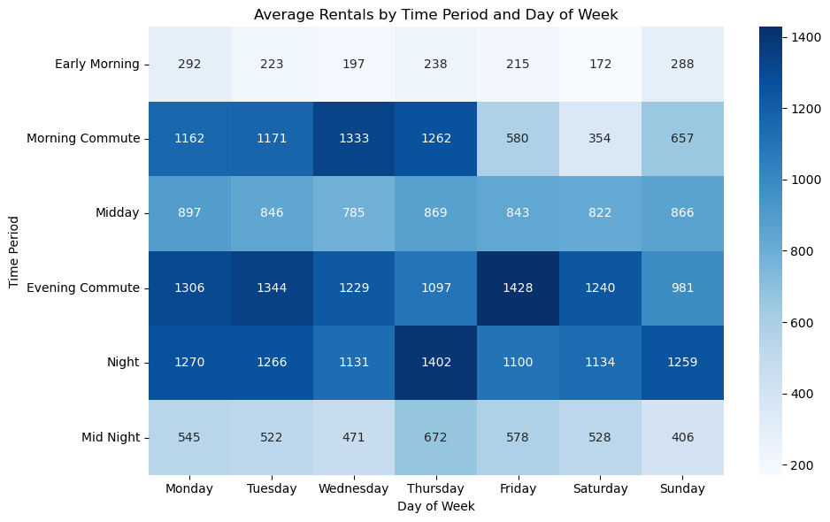

```python
# Call a heatmap function defined below
draw_heatmap()
```

## How do ideal weather conditions influence rentals?

Key Insight 1 : Rain significantly suppresses rentals.

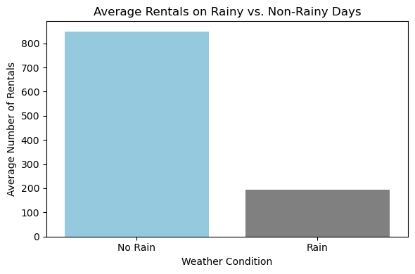

```python
# Execute a fucntiion to draw a comparison bar graph Rain vs No-Rain
draw_bar_graph_rain()
```

[output not shown]

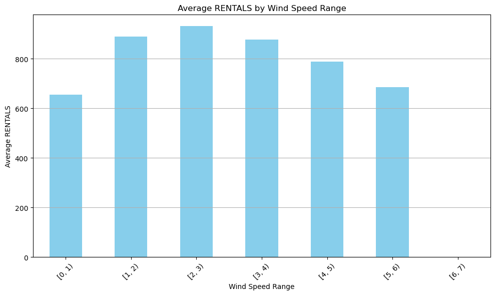

```python
# Call a histgram function defined below
draw_bar_graph_wind()
```

## Strategic Recommendations

**1. General Operations**

- Schedule recharging and bike maintenance during early morning hours when demand is low.
- On days with favorable weather, allocate more bikes to expected high-demand areas.

**2. Cluster 1: Weekday Commuters**

- On weekday mornings, redistribute bikes from downtown areas to residential zones and transit hubs so commuters easily find available bikes.
- After weekends, move bikes from downtown (likely used for weekend leisure) back to residential areas.

**3. Cluster 2: Daytime Shoppers**

- Partner with grocery stores and apparel brands to offer coupon-based incentives (e.g., cashback via QR on receipts).

**4. Cluster 1 & 2: Subscription Strategy**

- Launch a weekday-only subscription plan, targeting commuters and errand users.

```
(Anodot, n.d.)
```

**5. Cluster 3: Weekend Leisure Users**

- Collaborate with entertainment facilities or outlets to create weekend stamp-rally promotions, offering cashback for multi-stop leisure rides.

# Conclusion

This analysis reveals that bike rental demand is driven by a combination of user purpose, time of day, and weather conditions.

To capitalize on these insights, operators should not only optimize operational efficiency for existing users such as using early morning hours for strategic recharging and bike redistribution, but also consider growth strategies aimed at expanding the user base like partnering with retail and entertainment businesses to offer targeted promotions, leveraging weekday routines to attract commuter and errand-based users. And introducing flexible subscription models tailored to distinct user segments will work too.

Aligning services with real-world behavior will enable smarter fleet management and long-term demand generation.

# Coding (This section is for analysts or picky business person)

## Data load

```python
# This block is just to load the given excel
import pandas as pd

# define the excel file name
file_path = 'bikes_data.xlsx'

# read the excel file
df = pd.read_excel(file_path)

# show the first 5 rows to check
df.head()
```

|  | ID | Month | Day of Week | Hour | Temperature | Humidity | Wind Speed | Visibility | Dew Point Temperature | UV Index | Rainfall | Snowfall | Season | Holiday | RENTALS |
| --- | --- | --- | --- | --- | --- | --- | --- | --- | --- | --- | --- | --- | --- | --- | --- |
| 0 | 1 | Jan | Sunday | 0 | -3.2 | 40 | 0.5 | 1358 | -14.9 | 0.00 | 0.0 | 0.0 | Winter | Yes | 221 |
| 1 | 2 | Jan | Sunday | 13 | 2.4 | 22 | 2.3 | 1921 | -17.2 | 1.10 | 0.0 | 0.0 | Winter | Yes | 268 |
| 2 | 3 | Jan | Sunday | 16 | 3.0 | 28 | 2.5 | 1864 | -13.7 | 0.51 | 0.0 | 0.0 | Winter | Yes | 335 |
| 3 | 4 | Jan | Sunday | 17 | 1.8 | 33 | 3.3 | 1913 | -12.8 | 0.18 | 0.0 | 0.0 | Winter | Yes | 299 |
| 4 | 5 | Jan | Sunday | 20 | -0.3 | 40 | 1.2 | 1936 | -12.2 | 0.00 | 0.0 | 0.0 | Winter | Yes | 225 |

## Data preprocess

```python
# create a dataframe filtering out outliers
# rain / snow data should be excluded because bike drivers under snow or rain might have been too personal and strong purpose of rental
# rentals more than 2500 should be excluded because they are ourlier based on box-plot analysis
filtered_df = df[
    (df['Rainfall'] == 0) &
    (df['Snowfall'] == 0) &
    (df['RENTALS'] < 2500)
#     (df['Holiday'] == 'Yes') # Holiday was not that relevant based on my analysis
]
```

## Analysis -- Day and Week

```python
import pandas as pd
import seaborn as sns
import matplotlib.pyplot as plt

# Definine time range based on general life rhythm
def classify_time_period(hour):
    if 4 <= hour < 7:
        return 'Early Morning'
    elif 7 <= hour < 9:
        return 'Morning Commute'
    elif 9 <= hour < 16:
        return 'Midday'
    elif 16 <= hour < 19:
        return 'Evening Commute'
    elif 19 <= hour < 23:
        return 'Night'
    else:
        return 'Mid Night'

# add a new column, time_slot
filtered_df['Time Period'] = filtered_df['Hour'].apply(classify_time_period)

# Calculate mean of RENTALS based on time period and day of the week
pivot_table = filtered_df.pivot_table(
    index='Time Period',
    columns='Day of Week',
    values='RENTALS',
    aggfunc='mean'
)

# Clarify the order of day of week
day_order = ['Monday', 'Tuesday', 'Wednesday', 'Thursday', 'Friday', 'Saturday', 'Sunday']
pivot_table = pivot_table[day_order]
# Clarify the order of time period
time_order = ['Early Morning', 'Morning Commute', 'Midday', 'Evening Commute', 'Night', 'Mid Night']
pivot_table = pivot_table.reindex(time_order)

# define a function to draw a heatmap
def draw_heatmap():
    plt.figure(figsize=(10, 6))
    sns.heatmap(pivot_table, annot=True, fmt=".0f", cmap='Blues')
    plt.title("Average Rentals by Time Period and Day of Week")
    plt.ylabel("Time Period")
    plt.xlabel("Day of Week")
    plt.tight_layout()
    plt.show()
```

## Analysis -- Weather

### Correlation analysis to find a multi-collinearity parameter

-> Dew Point Temperature had a high correlation (r = 0.91) with Temperature, I removed it to avoid multicollinearity and retained Temperature as the representative variable.

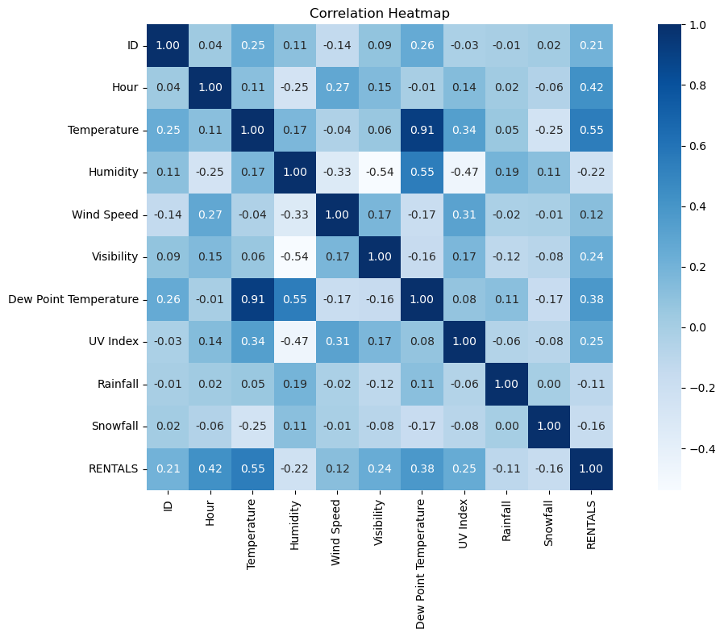

```python
import seaborn as sns
import matplotlib.pyplot as plt

# create correlation matrix using only numberic data
correlation_matrix = df.corr(numeric_only=True)

# draw a heatmap
plt.figure(figsize=(12, 8))
sns.heatmap(
    correlation_matrix,
    annot=True,              # Display numbers in each cell
    fmt=".2f",               # 2 digits
    cmap="Blues",            # Color is blue
    square=True,             # Cell is square
    cbar=True                # Display color bar at the side
)
plt.title("Correlation Heatmap")
plt.tight_layout()
plt.show()
```

### Boxplot analysis to find the outlier range of rantals

-> More than 2500 can be said outliers

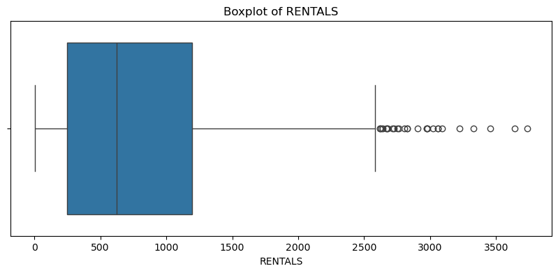

```python
import matplotlib.pyplot as plt
import seaborn as sns

# graph size
plt.figure(figsize=(10, 4))

# draw a boxplot
sns.boxplot(x=df['RENTALS'])

plt.title('Boxplot of RENTALS')
plt.xlabel('RENTALS')

plt.show()
```

### Comparison analysis Rain vs No_Rain

```python
import pandas as pd
import seaborn as sns
import matplotlib.pyplot as plt

# add a flag column, rain or no-rain
df['Rain_or_Not'] = df['Rainfall'].apply(lambda x: 'Rain' if x > 0 else 'No Rain')

# calculate mean of rentals of each group
avg_rentals = df.groupby('Rain_or_Not')['RENTALS'].mean().reset_index()

# create a bar graph
def draw_bar_graph_rain():
    plt.figure(figsize=(6, 4))
    sns.barplot(data=avg_rentals, x='Rain_or_Not', y='RENTALS', palette=['skyblue', 'gray'])

    plt.title('Average Rentals on Rainy vs. Non-Rainy Days')
    plt.xlabel('Weather Condition')
    plt.ylabel('Average Number of Rentals')
    plt.tight_layout()
    plt.show()
```

### Multi-regression analysis

-> Temperature, Humidity, Wind Speed, UV Index are relevant because their p-value are less than 5%

```python
import statsmodels.api as sm

# X = filtered_df[['Temperature', 'Humidity', 'Wind Speed', 'Visibility', 'UV Index']] # When tried with Visibility, it showed collinearity, so cut it out
X = filtered_df[['Temperature', 'Humidity', 'Wind Speed', 'UV Index']]
X = sm.add_constant(X)  # add an consistant factor
y = filtered_df['RENTALS']

# p value
model = sm.OLS(y, X).fit()
print(model.summary())
```

```
                            OLS Regression Results
==============================================================================
Dep. Variable:                RENTALS   R-squared:                       0.406
Model:                            OLS   Adj. R-squared:                  0.404
Method:                 Least Squares   F-statistic:                     203.9
Date:                Tue, 20 May 2025   Prob (F-statistic):          2.40e-133
Time:                        11:09:48   Log-Likelihood:                -9103.9
No. Observations:                1200   AIC:                         1.822e+04
Df Residuals:                    1195   BIC:                         1.824e+04
Df Model:                           4
Covariance Type:            nonrobust
===============================================================================
                  coef    std err          t      P>|t|      [0.025      0.975]
-------------------------------------------------------------------------------
const         893.1944     63.000     14.178      0.000     769.591    1016.798
Temperature    36.8970      1.401     26.331      0.000      34.148      39.646
Humidity       -9.9574      0.905    -11.008      0.000     -11.732      -8.183
Wind Speed     40.5334     14.787      2.741      0.006      11.522      69.545
UV Index     -111.0887     20.248     -5.486      0.000    -150.815     -71.363
==============================================================================
Omnibus:                       72.994   Durbin-Watson:                   1.413
Prob(Omnibus):                  0.000   Jarque-Bera (JB):               87.151
Skew:                           0.598   Prob(JB):                     1.19e-19
Kurtosis:                       3.560   Cond. No.                         285.
==============================================================================

Notes:
[1] Standard Errors assume that the covariance matrix of the errors is correctly specified.
```

### Histogram analysis of wind speed

-> Optimal wind speed is 2-3

```python
import pandas as pd
import matplotlib.pyplot as plt

# Set
filtered_df['Wind_bin'] = pd.cut(filtered_df['Wind Speed'], bins=[0, 1, 2, 3, 4, 5, 6, 7], right=False)

# 各ビンにおける平均RENTALSを計算
bin_avg = filtered_df.groupby('Wind_bin')['RENTALS'].mean()

def draw_bar_graph_wind():
    # 描画
    plt.figure(figsize=(10, 6))
    bin_avg.plot(kind='bar', color='skyblue')

    # ラベルとタイトル
    plt.xlabel('Wind Speed Range')
    plt.ylabel('Average RENTALS')
    plt.title('Average RENTALS by Wind Speed Range')
    plt.xticks(rotation=45)
    plt.grid(axis='y')
    plt.tight_layout()
    plt.show()
```